# Final Project

Zhiyuan Deng

1. Import and tweak the data before the analysis

```r
my.salary <- read.csv("../salaries.csv") # Import the data
summary(my.salary) # Inspect the data
```

```
##        X              rank     discipline yrs.since.phd    yrs.service
##  Min.   :  1   AssocProf: 64   A:181      Min.   : 1.00   Min.   : 0.00
##  1st Qu.:100   AsstProf : 67   B:216      1st Qu.:12.00   1st Qu.: 7.00
##  Median :199   Prof     :266              Median :21.00   Median :16.00
##  Mean   :199                              Mean   :22.31   Mean   :17.61
##  3rd Qu.:298                              3rd Qu.:32.00   3rd Qu.:27.00
##  Max.   :397                              Max.   :56.00   Max.   :60.00
##      sex          salary
##  Female: 39   Min.   : 57800
##  Male  :358   1st Qu.: 91000
##               Median :107300
##               Mean   :113706
##               3rd Qu.:134185
##               Max.   :231545
```

```r
colnames(my.salary)[1] <- "ID" # change the name for the first column
my.salary$ID <- as.character(my.salary$ID) # change the data type from int to chr
my.salary$rank <- relevel(my.salary$rank, "Prof")
levels(my.salary$rank) <- c("Professor", "Associate Professor", "Assistant Professor") # rename the levels for rank
head(my.salary)
```

```
##   ID                rank discipline yrs.since.phd yrs.service  sex salary
## 1  1           Professor          B            19          18 Male 139750
## 2  2           Professor          B            20          16 Male 173200
## 3  3 Assistant Professor          B             4           3 Male  79750
## 4  4           Professor          B            45          39 Male 115000
## 5  5           Professor          B            40          41 Male 141500
## 6  6 Associate Professor          B             6           6 Male  97000
```

## Objective 1

I want to present visualized results showing the mean salary for professors by academic rank, discipline, and gender.

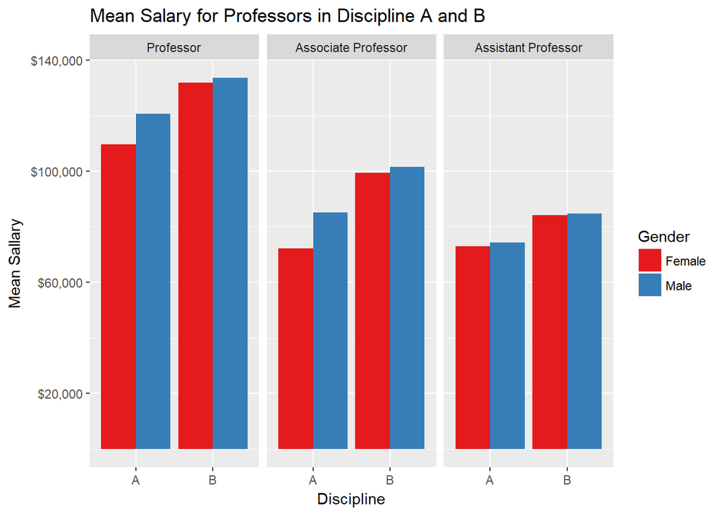

```r
salary.means <- summarize(group_by(my.salary, discipline, rank, sex), mean.salary = mean(salary)) # get the data (mean salary) to be plotted
ggplot(salary.means, aes(discipline, mean.salary)) + geom_bar(aes(fill = sex), stat = "identity", position = "dodge") + scale_x_discrete(name = "Discipline") + scale_y_continuous(breaks = seq(20000, 200000, 40000), name = "Mean Sallary", labels = dollar) + scale_fill_brewer(palette = "Set1", name = "Gender") + facet_wrap(~ rank) + ggtitle("Mean Salary for Professors in Discipline A and B")
```

## Objective 2

I want to conduct a t-test to see if there is a significant difference between the salaries for male and female professors.

```r
male.data <- my.salary[my.salary$sex == "Male", ]
female.data <- my.salary[my.salary$sex == "Female", ] # two subsets to be compared (male vs. female)

overall.results <- t.test(female.data$salary, male.data$salary) # results for the overall data
overall.results
```

```
##
##  Welch Two Sample t-test
##
## data:  female.data$salary and male.data$salary
## t = -3.1615, df = 50.122, p-value = 0.002664
## alternative hypothesis: true difference in means is not equal to 0
## 95 percent confidence interval:
##  -23037.916  -5138.102
## sample estimates:
## mean of x mean of y
##  101002.4  115090.4
```

Based on the overall results, it seems that there is a significant difference between the salary for female and male professors. However, in my data set, the sample size for females is fairly small compared to the males, and there might be other differences, like maybe the women are on average not as senior.

Therefore, I want to find a matched sample of men, and see how that matched sample compares to the female group. This process will be performed for 10000 times, in order to provide something like a bootstrapped estimate of what it looks like when a matched smaller group of men is compared to the female group.

```r
male.prof.data <- male.data[male.data$rank == "Professor", ]
male.assoc.data <- male.data[male.data$rank == "Associate Professor", ]
male.asst.data <- male.data[male.data$rank == "Assistant Professor", ]

female.prof.data <- female.data[female.data$rank == "Professor", ]
female.assoc.data <- female.data[female.data$rank == "Associate Professor", ]
female.asst.data <- female.data[female.data$rank == "Assistant Professor", ] # subset the data so that a matched sample of men can be found

n.sim <- 10000
boot.results <- data.frame(sim = 1:n.sim, statistic = NA, p.val = NA, significance = NA) # create a data frame to store the results
for(sim in 1:n.sim) {
  if(sim %% 1000 == 0) {
    print(paste("starting simulation", sim))
  }
  sim.data.part1 <- male.prof.data[sample(nrow(female.prof.data), replace = TRUE), "salary"]
  sim.data.part2 <- male.assoc.data[sample(nrow(female.assoc.data), replace = TRUE), "salary"]
  sim.data.part3 <- male.asst.data[sample(nrow(female.asst.data), replace = TRUE), "salary"]
  sim.data <- c(sim.data.part1, sim.data.part2, sim.data.part3) # sample a matched male group
  ttest.results <- t.test(female.data$salary, sim.data)
  statistic <- ttest.results$statistic # save the results
  boot.results[sim, "statistic"] <- statistic
  p.val <- ttest.results$p.value
  boot.results[sim, "p.val"] <- p.val
  if (p.val < 0.05) {
    boot.results[sim, "significance"] <- "Yes"
  } else {
    boot.results[sim, "significance"] <- "No"
  }
}
```

```
## [1] "starting simulation 1000"
## [1] "starting simulation 2000"
## [1] "starting simulation 3000"
## [1] "starting simulation 4000"
## [1] "starting simulation 5000"
## [1] "starting simulation 6000"
## [1] "starting simulation 7000"
## [1] "starting simulation 8000"
## [1] "starting simulation 9000"
## [1] "starting simulation 10000"
```

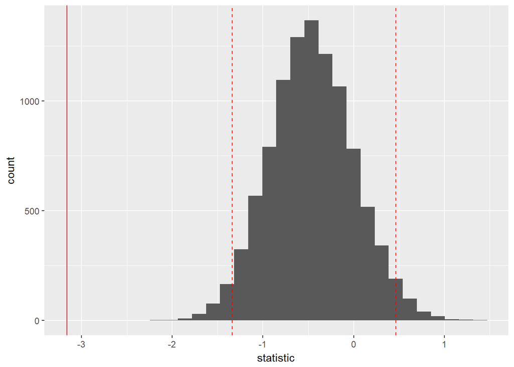

```r
bottom.top.t <- quantile(boot.results$statistic, c(.025, .975))

ggplot(boot.results, aes(statistic)) + geom_histogram() + geom_vline(xintercept = overall.results$statistic, color = "red") + geom_vline(xintercept = bottom.top.t[1], color = "red", linetype = 2) + geom_vline(xintercept = bottom.top.t[2], color = "red", linetype = 2) # make comparisons (t-value)
```

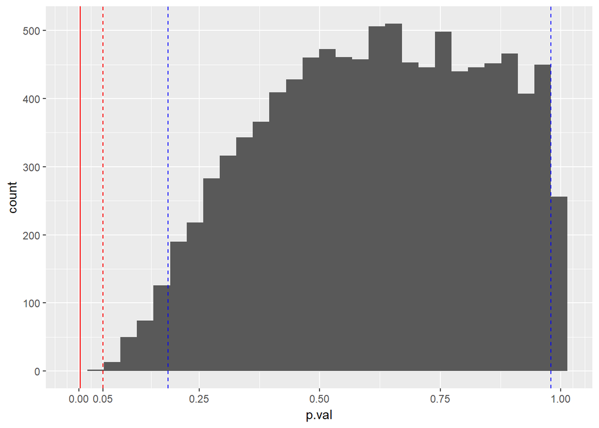

```r
bottom.top.p <- quantile(boot.results$p.val, c(.025, .975))

ggplot(boot.results, aes(p.val)) + geom_histogram() + geom_vline(xintercept = overall.results$p.value, color = "red") + geom_vline(xintercept = bottom.top.p[1], color = "blue", linetype = 2) + geom_vline(xintercept = bottom.top.p[2], color = "blue", linetype = 2) + geom_vline(xintercept = 0.05, color = "red", linetype = 2) + scale_x_continuous(breaks = c(0.00, 0.05, 0.25, 0.50, 0.75, 1.00)) # make comparisons (p-value)
```

The results seem to indicate that when a matched group of men is sampled, there is not a significant difference between their salary and the salary for the female group. (Due to my limited statistical knowledge, I am not sure if what I did is a legitimate analysis, and I am not sure if my interpretation is correct. I look forward to your feedback.)

## Objective 3

I want to conduct linear regression analysis to see if salaries for professors are predicted by years of service.

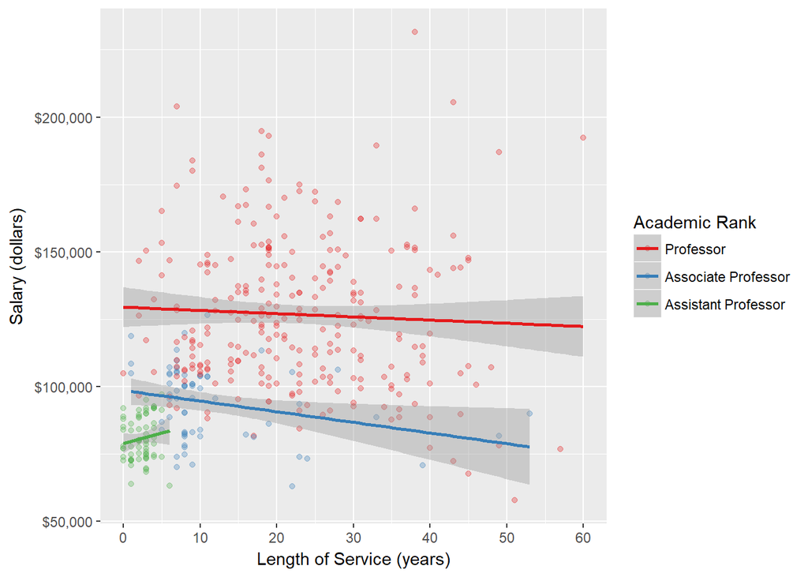

```r
ggplot(my.salary, aes(yrs.service, salary, color = rank)) + geom_point(alpha = .3) +
  geom_smooth(method = "lm") +
  scale_x_continuous(breaks = seq(0, 60, 10), name = "Length of Service (years)") +
  scale_y_continuous(breaks = seq(50000, 250000, 50000), name = "Salary (dollars)", label = dollar) +
  scale_color_brewer(palette = "Set1", name = "Academic Rank") +
  theme(text=element_text(size=12, family="serif")) +
  theme_grey()
```

```r
lm.results <- list("Professor", "Associate Professor", "Assistant Professor") # create a list to save the results
for (this.rank in levels(my.salary$rank)) {
  lm.result <- lm(salary ~ yrs.service, my.salary[my.salary$rank == this.rank, ])
  lm.results[[this.rank]] <- lm.result
} # conduct analysis in a loop

lm.results$`Professor`
```

```
##
## Call:
## lm(formula = salary ~ yrs.service, data = my.salary[my.salary$rank ==
##     this.rank, ])
##
## Coefficients:
## (Intercept)  yrs.service
##    129494.4       -119.3
```

```r
lm.results$`Associate Professor`
```

```
##
## Call:
## lm(formula = salary ~ yrs.service, data = my.salary[my.salary$rank ==
##     this.rank, ])
##
## Coefficients:
## (Intercept)  yrs.service
##     98594.3       -394.7
```

```r
lm.results$`Assistant Professor`
```

```
##
## Call:
## lm(formula = salary ~ yrs.service, data = my.salary[my.salary$rank ==
##     this.rank, ])
##
## Coefficients:
## (Intercept)  yrs.service
##     78926.6        779.3
```